# (Investigation of Ford GoBike System Data)

## by (Ahmed Said)

## Investigation Overview

> Here , we will analyze the data set of Ford GoBike System Data and get some relations between the data set features

## Dataset Overview

> this data set is a data set about Ford GoBike System Data happened in April 2018 , it has the following features:-
> - Trip Duration (seconds)
> - Start Time and Date
> - End Time and Date
> - Start Station ID
> - Start Station Name
> - Start Station Latitude
> - Start Station Longitude
> - End Station ID
> - End Station Name
> - End Station Latitude
> - End Station Longitude
> - Bike ID
> - User Type (Subscriber or Customer – “Subscriber” = Member or “Customer” = Casual)
- Dataset Source https://www.lyft.com/bikes/bay-wheels/system-data

## (Average duration in minutes)

> Average duration of trips in minutes to be will organized abd visualized instead of seconds
> - the segnificant average trip duration is 10 minutes

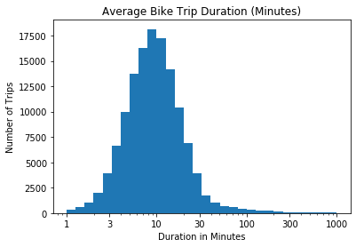

```python
# here we will convert the duration_sec to minutes to be easy to understand and visulaize
df_fb['duration_min'] = df_fb['duration_sec'] / 60
#we will make Log transformation to better understand the data
bins = 10**np.arange(0 , 3 + 0.1 , 0.1)
ticks =  [ 1 , 3, 10, 30, 100, 300, 1000]
labels = ['{}'.format(v) for v in ticks]
plt.hist(data = df_fb , x = 'duration_min' , bins = bins);
plt.xscale('log');
plt.xticks(ticks,labels);
plt.xlabel('Duration in Minutes');
plt.title('Average Bike Trip Duration (Minutes)');
plt.ylabel('Number of Trips');
```

## (most frequent start hours of the trip in the day)

> The most frequent hours of start time in the day are 8 am and 5 pm

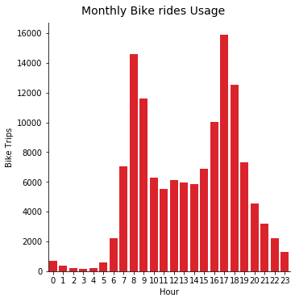

```python
df_fb['Hour'] = pd.DatetimeIndex(df_fb['start_time']).hour

g = sb.catplot(data=df_fb, x='Hour', kind='count', color='#F90510')
g.set_axis_labels("Hour", "Bike Trips")
g.fig.suptitle('Monthly Bike rides Usage', y=1.03, fontsize=14);
```

## (Relation between Start Hour and User_Type)

> There are segnificant appear for both user types in the 5 pm Hr and the subscribers has segnificant appear at 8 am

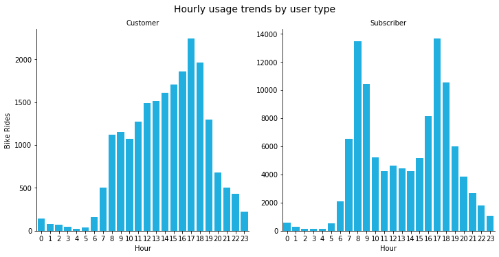

```python
g = sb.catplot(data=df_fb, x='Hour', col="user_type", kind='count', sharey = False, color = 'deepskyblue')
g.set_axis_labels("Hour", "Bike Rides")
g.set_titles("{col_name}")
g.fig.suptitle('Hourly usage trends by user type', y=1.03, fontsize=14);
```

## (Relation between user type and the duration of the trip)

> As we discovered here although we have the large amount of user types are subscribers but the average duration of customer types are higher than avarage duration of subscribers

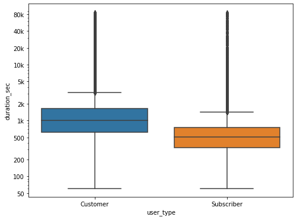

```python
# let`s explore the relationship between duarion and user_type using boxplot
plt.figure(figsize=[8,6])
sb.boxplot(data=df_fb, x='user_type', y='duration_sec')
plt.yscale('log')
plt.yticks([50,100,200,500, 1e3, 2e3, 5e3, 1e4, 2e4,4e4,8e4], [50,100,200,500, '1k', '2k', '5k', '10k', '20k','40k','80k']);
```

## (Relation between start hour and trip duration and user type)

> As Discovered from the graph
> - The user type of the customer has the longest duration trip at 4 am and 5 am
> - The user type of the subscriber has the longest duration trip at 1 am and 11 pm

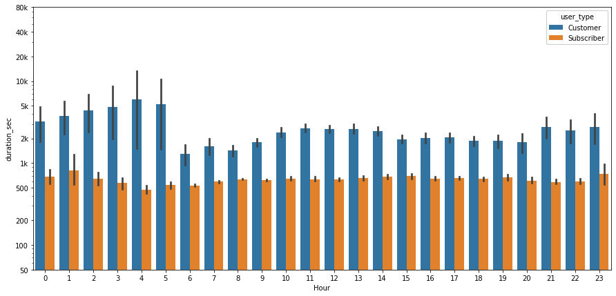

```python
plt.figure(figsize=[15,7])
ax = sb.barplot(data = df_fb, x = 'Hour', y = 'duration_sec', hue = 'user_type')
ax.legend(loc = 1, framealpha = 1, title = 'user_type')
plt.yscale('log')
plt.yticks([50,100,200,500, 1e3, 2e3, 5e3, 1e4, 2e4,4e4,8e4], [50,100,200,500, '1k', '2k', '5k', '10k', '20k','40k','80k']);
```

```python
### Thanks
```